# damidBind

Owen J. Marshall

Menzies Institute for Medical Research, University of Tasmania

owen.marshall@utas.edu.au

25 July 2025

#### Abstract

The damidBind package provides a means of determining differential binding/gene transcription/chromatin accessibility for DamID-seq data (differential binding = conventional DamID / TaDa for TFs; differential transcription = TaDa for RNA polymerase occupancy; chromatin accessibility = CATaDa). The package loads processed bedgraphs and peaks files, processes these, uses limma (for DamID log2 ratios) or NOIseq (for CATaDa counts data) to determine differentially bound/transcribed/accessible loci, and then provides visualisation via volcano plots, GSEA lollipop plots, Venn diagrams, and an igvShiny interface to quickly view each differentially bound locus in an IGV browser, with the ranked, sorted differentially bound loci listed in an adjacent interactable table.

#### Package

damidBind 0.99.0

# 1 Introduction

DamID (van Steensel & Henikoff, 2000; van Steensel *et al*, 2001) is a highly-sensitive means to profile the genome-wide association of proteins with chromatin in living eukaryotic cells, without fixation or the use of antibodies. Cell-type specific techniques such as Targeted DamID (Southall *et al*, 2013; Marshall *et al*, 2016) to profile protein binding, and CATaDA (Aughey *et al*, 2018) to profile chromatin accessibility, have made the technique an extremely powerful tool to understand the binding of transcription factors, chromatin proteins, RNA polymerase and chromatin changes during development and disease.

Despite the technique’s growing popularity and adoption, no formal analysis pipeline or R package exists to analyse and explore differential DamID binding, gene transcription or chromatin accessibility between two conditions. The `damidBind` package provides this functionality.

*damidbind* imports processed data from DamID-seq experiments in the form of binding bedgraphs and GFF peak calls. After optionally normalising data, combining peaks across replicates and determining per-replicate peak occupancy, the package links bound loci to nearby genes. It then uses either *limma* (for conventional log2 ratio DamID binding data) or *NOIseq* (for counts-based CATaDa chromatin accessibility data) to identify differentially-enriched regions between two conditions. The package provides a number of visualisation tools (volcano plots, GSEA plots, Venn diagrams) for downstream data exploration and analysis. An interactive IGV genome browser interface (powered by *Shiny* and *igvShiny*) allows users to rapidly and intuitively assess significant differentially-bound regions.

Although extensive customisation options are available if required, much of the data handling by `damidBind` is taken care of automatically, with sensible defaults assumed. To move from loading raw data to visualising differentially-enriched regions on a volcano plot or browsing enriched regions in an interactive IGV window is a simple three command procedure.

# 2 Quick start guide

Using `damidBind`, in seven easy steps:

```r
## Example code only, not run:

# Load up the data (use load_data.genes() for RNA Polymerase occupancy data)
input <- load_data.peaks(
  binding_profiles_path = "path/to/binding_profile_bedgraphs",
  peaks_path = "path/to/peak_gffs_or_beds"
) # add quantile_norm = T if appropriate

# Deterimine differential binding  (use differential_accesibility() for CATaDa chromatin accessibility data)
input.diff <- differential_binding(
  input,
  cond = c(
    "Condition 1 identifying string in filenames",
    "Condition 2 identifying string in filenames"
  )
)

# The result 'input.diff' is a formal S4 object.
# You can see a summary by simply typing its name:
input.diff

# View the proporition of differentially bound loci
plot_venn(input.diff)

# Plot the differential binding, labelling associated genes with outliers
plot_volcano(input.diff)

# Analyse GO enrichment in peaks associated with one condition
analyse_go_enrichment(
  input.diff,
  direction = "Condition 1 identifier set with differential_binding() above"
)

# View the differentially bound regions in an IGV browser window, with an interactive table of bound regions
browse_igv_regions(input.diff)

# Apply additional functions on the differential binding results
# Use the '@' accessor to get data 'slots' from the S4 object
my_custom_function(input.diff@analysis)
```

# 3 Sample data examples

## 3.1 Sample input data (provided within the package)

`damidBind` provides a simple, truncated dataset with the package for immediate testing. Owing to package space, this sample dataset uses only *Drosophila melanogaster* Chr2L binding, and should not be used for any actual analysis.

## 3.2 Sample input data (provided online through a Zenodo repository)

Three previously-published sample datasets have been deposited in Zenodo and are made available for exploring the features and capabilities of `damidBind`:

- Bsh transcription factor binding in L4 and L5 neurons of the *Drosophila* lamina (Xu *et al*, 2024)
- CATaDa chromatin accessibility data in L4 and L5 neurons (Xu *et al*, 2024)
- RNA Polymerase II occupancy in *Drosophila* larval neural stem cells and adult neurons. (Marshall & Brand, 2017)

# 4 Data preparation

## 4.1 Input data format

`damidBind` takes as input:

- Genome-wide binding profile tracks in BEDGRAPH format (external files) or *GenomicRanges* format (internal)
  - For standard DamID binding datasets, the score column is expected to be a log2 ratio
  - For CATaDa chromatin accessibility datasets, the score column should be in CPM (counts per million reads) or similar
- Significant peaks files in GFF or BED format (external files) or *GenomicRanges* format (internal)
  - Peaks are not required when comparing differential gene expression via RNA Polymerase occupancy.

All external data files are read using *rtracklayer* and can be gzip compressed or uncompressed as required.

## 4.2 Input data generation

`damidBind` can work with either raw data files or preprocessed data in *GenomicRanges* format.

### 4.2.1 BEDGRAPH binding / accessibility profiles

We recommend that damidseq_pipeline is used to generate input files:

- Using default options to generate log2 ratio protein binding BEDGRAPHs
- Using the `--catada` flag on Dam-only samples to generate count-based CATaDa accesibility BEDGRAPHs

### 4.2.2 Peak GFF files

We recommend that find_peaks is used to generate peak files on each DamID / CATaDa BEDGRAPH file replicate:

- In all cases, the default options of `--min_quant=0.8 --unified_peaks=min` are recommended

# 5 Using damidBind

Load the library

```r
library(damidBind)
```

## 5.1 Loading data

A small example dataset is provided with `damidbind`. The dataset is derived from the binding of Bsh in L4 and L5 neurons of the *Drosophila melanogaster* lamina (Xu *et al*, 2024), truncated to chromosome 2L. The raw data was processed using `damidseq_pipeline` and peaks called using `find_peaks` (see the publication Methods for more details).

To load up the data, we only need to know the path to the installed example datafiles:

```r
data_dir = system.file("extdata", package = "damidBind")

# Show the files present for clarity in this vignette example:
files <- list.files(data_dir)
print(files)
```

```
## [1] "Bsh_Dam_L4_r1-ext300-vs-Dam.kde-norm.gatc-FDR0.01.peaks.2L.bed.gz"
## [2] "Bsh_Dam_L4_r1-ext300-vs-Dam.kde-norm.gatc.2L.bedgraph.gz"
## [3] "Bsh_Dam_L4_r2-ext300-vs-Dam.kde-norm.gatc-FDR0.01.peaks.2L.bed.gz"
## [4] "Bsh_Dam_L4_r2-ext300-vs-Dam.kde-norm.gatc.2L.bedgraph.gz"
## [5] "Bsh_Dam_L5_r1-ext300-vs-Dam.kde-norm.gatc-FDR0.01.peaks.2L.bed.gz"
## [6] "Bsh_Dam_L5_r1-ext300-vs-Dam.kde-norm.gatc.2L.bedgraph.gz"
## [7] "Bsh_Dam_L5_r2-ext300-vs-Dam.kde-norm.gatc-FDR0.01.peaks.2L.bed.gz"
## [8] "Bsh_Dam_L5_r2-ext300-vs-Dam.kde-norm.gatc.2L.bedgraph.gz"
```

And then we can use `damidBind` on the data. First, we load up the data. There are two potential commands that can be used for data loading, depending on the data being analysed:

**`load_data.peaks()`**

Used to load binding data with associated peaks files (e.g. transcription factor binding, CATaDa accessibility)

**`load_data.genes()`**

Used to load RNA Polymerase occupancy DamID data (as a proxy for gene expression, as per Marshall & Brand (2015)). For these data, no peak files are required (as occupancy is calculated over the gene bodies).

In this case, we’re dealing with the binding of the transcription factor Bsh, so we’ll use the `load_data.peaks()`. As this is the same transcription factor being profiled in two different cell types, and we’d expect the binding distribution to be similar, we’ll use quantile normalisation on the datasets.

```r
input.bsh = load_data.peaks(
  binding_profiles_path = data_dir,
  peaks_path = data_dir,
  quantile_norm = T
)
```

```
## Finding genome versions ...
```

```
## Loading Ensembl genome version 'Ensembl 112 EnsDb for Drosophila melanogaster'
```

```
## loading from cache
```

```
## require("ensembldb")
```

```
## Locating binding profile files
```

```
## Building binding profile dataframe from input files ...
```

```
##  - Loaded: Bsh_Dam_L4_r1-ext300-vs-Dam.kde-norm
```

```
##  - Loaded: Bsh_Dam_L4_r2-ext300-vs-Dam.kde-norm
```

```
##  - Loaded: Bsh_Dam_L5_r1-ext300-vs-Dam.kde-norm
```

```
##  - Loaded: Bsh_Dam_L5_r2-ext300-vs-Dam.kde-norm
```

```
## Applying quantile normalisation
```

```
## Locating peak files
```

```
## Calculating occupancy over peaks
```

```
## Calculating average occupancy per region ...
```

## 5.2 Analysing differential binding

Now, we’ll determine the differential binding of Bsh between L4 and L5 neurons. Our input files use `L4` and `L5` labels to distinguish the samples, and that’s all we need to know here.

Again, there are two different analysis options depending on the data type:

**`differential_binding()`**

Analyses conventional DamID data (including RNA Polymerase DamID) present as a log2(Dam-fusion/Dam-only) ratio. All standard DamID data is in this format. *limma* is used as the backend for analysis.

**`differential_accessibility()`**

Analyses CATaDa data (Dam-only chromatin accessibility data) present as Counts Per Million reads (CPM) or raw counts. Only CATaDa data (generated via e.g. `damidseq_pipeline --catada`) should be used with this function. Given the counts nature of these data, *NOISeq* is used as the analysis backend.

The input from `load_data.peaks()` or `load_data.genes()` feeds directly into these functions.

Here, we’re not dealing with CATaDa data, so we’ll use `differential_binding()` to find the significant, differentially-bound loci between the two conditions:

```r
diff.bsh = differential_binding(
  input.bsh,
  cond = c("L4","L5"),
  cond_names = c("L4 neurons","L5 neurons")
)
```

```
## Differential analysis setup:
```

```
## Condition 1: 'L4' (display as 'L4 neurons')
```

```
##   Found 2 replicates:
##     Bsh_Dam_L4_r1-ext300-vs-Dam.kde-norm_qnorm
##     Bsh_Dam_L4_r2-ext300-vs-Dam.kde-norm_qnorm
```

```
## Condition 2: 'L5' (display as 'L5 neurons')
```

```
##   Found 2 replicates:
##     Bsh_Dam_L5_r1-ext300-vs-Dam.kde-norm_qnorm
##     Bsh_Dam_L5_r2-ext300-vs-Dam.kde-norm_qnorm
```

```
## limma contrasts: L4-L5
```

```
##
## 277 loci enriched in L4 neurons
```

```
## Highest-ranked genes:
## Bka,RpS2,snoRNA:Me18S-A1576,snoRNA:Me18S-G1620,snoRNA:U14:30Ea,snoRNA:U14:30Eb,Uhg2, MICU1, oaf,Slh, CG15880,Pex12,Saf6, CG17544,Pax, CG17490,lncRNA:CR46268,RpL5,snoRNA:Psi28S-2996, haf,Rab3GAP1, CG11927,mxt, CG15425,lncRNA:CR45294,lncRNA:CR45295,lncRNA:CR45296, AIF,TBCD
```

```
##
## 173 loci enriched in L5 neurons
```

```
## Highest-ranked genes:
## beat-Ic, Ance-3, CG11634, CG13946, Ugt36F1, Ccdc85, dmGlut,lncRNA:CR44587, CG10237, lncRNA:CR43314, eya
```

Please note the required `cond` parameter to this function, which specifies the filename text that distinguished the two separate conditions to test. `cond[1]` must be a text string present in all, and only all, of the filenames of the **first** condition to test; `cond[2]` must be a text string present in all, and only all, of the filenames of the **second** condition to test.

The use of `cond_names` here is optional, and provides display names for the conditions for downstream visualisation.

Note that when run, `differential_binding` (or `differential_accessibility`) will list the replicates found under each condition. The package attempts to ensure that condition search overlaps are avoided, but please check that all replicates have been correctly assigned.

The function output provides a quick “top ten” list of genes associated with the most significant, differentially bound loci. This is provided for a quick verification that the analysis was worked correctly, and does not imply any special value to the listed genes beyond that. The function returns a `DamIDResults` object.

```r
# See a summary of the results object
diff.bsh
```

```
## An object of class 'DamIDResults'
## Comparison: 'L4 neurons' vs 'L5 neurons'
## - 277 regions enriched in L4 neurons
## - 173 regions enriched in L5 neurons
## - 1208 total regions tested
## Access results with the '@' accessor, e.g., object@analysis
```

To fully explore the differentially bound loci, use one of the visualisation functions below.

## 5.3 Visualising data

All downstream visualisation / data exploration functions take the `DamIDResults` object returned from the analysis functions `differential_binding()` or `differential_accessibility()`.

### 5.3.1 Venn diagrams of differentially bound loci

```
## [1] "x total: 1035"
## [1] "y total: 931"
## [1] "z total: 0"
## [1] "x only: 277"
## [1] "y only: 173"
## [1] "z only: 0"
## [1] "x-y total overlap: 758"
## [1] "x-z total overlap: 0"
## [1] "y-z total overlap: 0"
## [1] "x-y only overlap: 758"
## [1] "x-z only overlap: 0"
## [1] "y-z only overlap: 0"
## [1] "x-y-z overlap: 0"
```

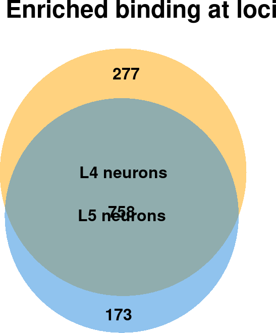

Figure 1: A venn diagram of significantly bound loci by Bsh in L4 and L5 neurons  
The exclusive parts of each set represent regions that are differentially bound between the two conditions.

```r
plot_venn(diff.bsh)
```

### 5.3.2 Volcano plots

`damidBind` comes with a comprehensive volcano plot function. The following gives some idea as to the capabilities.

#### 5.3.2.1 The default volcano plot

The simple volcano plot already gives a clear picture of differentially bound loci and their associated genes.

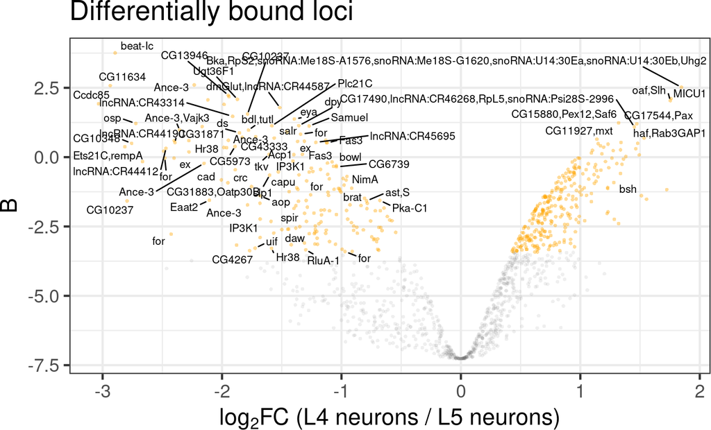

Figure 2: Differential binding of Bsh in L4 and L5 neuronal subtypes  
Genes associated with differentially bound peaks are displayed; the limitations of label overlaps means that only outliers are labelled. (Dataset from chromosome 2L only)

```r
plot_volcano(
  diff.bsh
)
```

#### 5.3.2.2 Cleaning up the gene names

However, a lot of plot label space can be taken up by generally uninformative snoRNA / tRNA genes. We can optionally remove these from the plot using the `clean_names=T` parameter, to show more potentially informative labels.

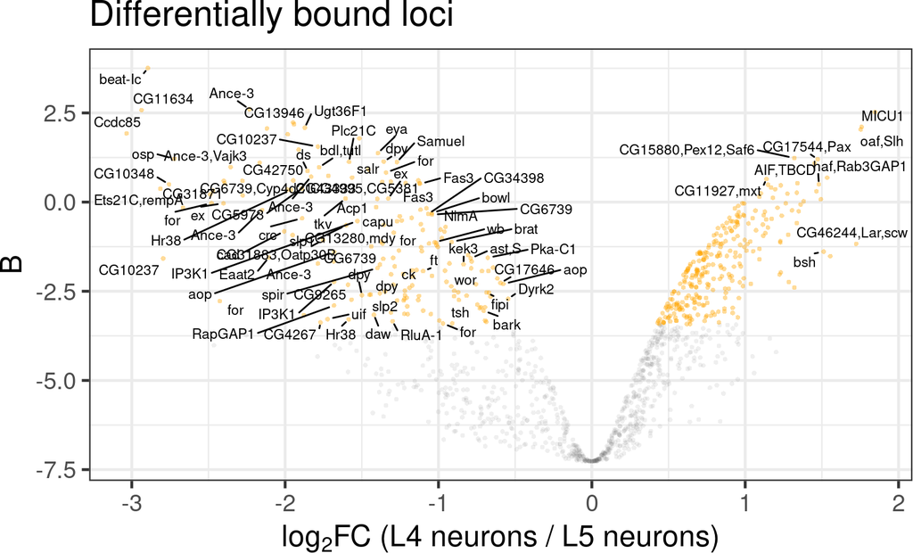

Figure 3: Differential binding of Bsh in L4 and L5 neuronal subtypes  
Genes associated with differentially bound peaks are displayed, after some common, but less useful, gene label classes are removed. (Dataset from chromosome 2L only)

```r
plot_volcano(
  diff.bsh,
  label_config = list(clean_names=T)
)
```

Already, that’s becoming a lot clearer.

#### 5.3.2.3 Highlighting gene groups

But, what if we now wanted to highlight genes bound by Bsh, that are only expressed in L4 neurons? (data from scRNA-seq data, provided in Supplementary Files 2 & 3 of (Xu *et al*, 2024)). This is straightforward to do:

```
## Highlight group 'L4 specific' will label: oaf,Slh, osp, CG10019, Adh,Adhr,lncRNA:CR43411,osp, oaf, CG31688, ,Btk,CG8086,mir-2b-1, Ca-Ma2d, CG14402,twit, CG42748, BicD,Sgt, lncRNA:CR45363,Traf4, bru2, lncRNA:CR45363,Traf4, bru2, CG33090,ms(2)34Fe, bru2, CG10019, CG14400,CG9336,twit, osp, CG31688,l…
```

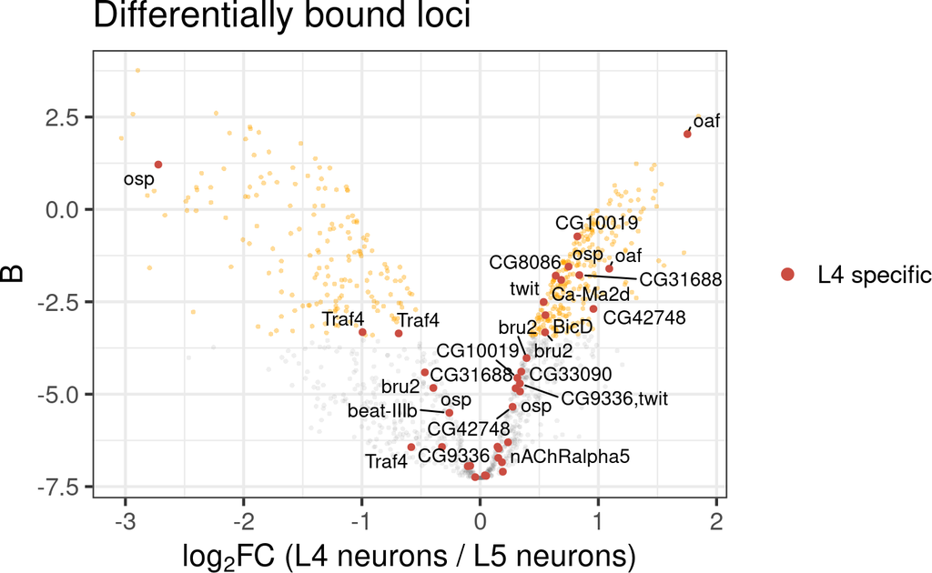

Figure 4: Differential binding of Bsh in L4 and L5 neuronal subtypes  
Genes that are specifically expressed in L4 neurons are highlighted. (Dataset from chromosome 2L only)

```r
L4_only_genes = c("Mp", "tnc", "grn", "rut", "mtd", "rdgB", "Octbeta2R", "msi", "Octbeta3R", "beat-IIIb", "ap", "Fili", "LRP1", "CG7378", "CG13698", "twit", "CG9336", "tok", "CG12991", "dpr1", "CG42339", "beat-IIb", "mav", "CG34377", "alpha-Man-IIb", "Pli", "CG32428", "osp", "Pka-R2", "CG15202", "CG8916", "CG15894", "side", "CG42258", "CHES-1-like", "SP2353", "CG44838", "Atg1", "Traf4", "DIP-beta", "KCNQ", "metro", "nAChRalpha1", "path", "CG10527", "Pde8", "CG30116", "CG7985", "CG1688", "dpr12", "pigs", "Eip63F-1", "CG14795", "2mit", "CG42340", "BicD", "CG18265", "hppy", "5-HT1A", "Chd64", "CG33090", "Dyb", "Btk29A", "Apc", "Rox8", "nAChRalpha5", "CG42748", "CG3257", "CG2269", "beat-IV", "CG8086", "glec", "CG31688", "oaf", "Drl-2", "CG8188", "aos", "CG31676", "REPTOR", "RabX4", "alt", "Pura", "DIP1", "ewg", "side-VIII", "nAChRalpha7", "Alh", "kug", "Ca-Ma2d", "bru2", "CG43737", "lncRNA:CR44024", "lncRNA:CR46006", "Had1", "CG3961", "comm", "Toll-6", "CG13685", "tow", "CG10019")

plot_volcano(
  diff.bsh,
  label_config = NULL,
  highlight = list(
    "L4 specific" = L4_only_genes
  ),
  highlight_config = list(
    size=1.5,
    label=T
  )
)
```

Although this is just a truncated sample from chr 2L, the link between a subset of Bsh binding and potential upregulation in this lineage is apparent.

We could also compare this against genes bound by Bsh and only expressed in L5 neurons. For clarity, we’ll drop gene labels from this plot.

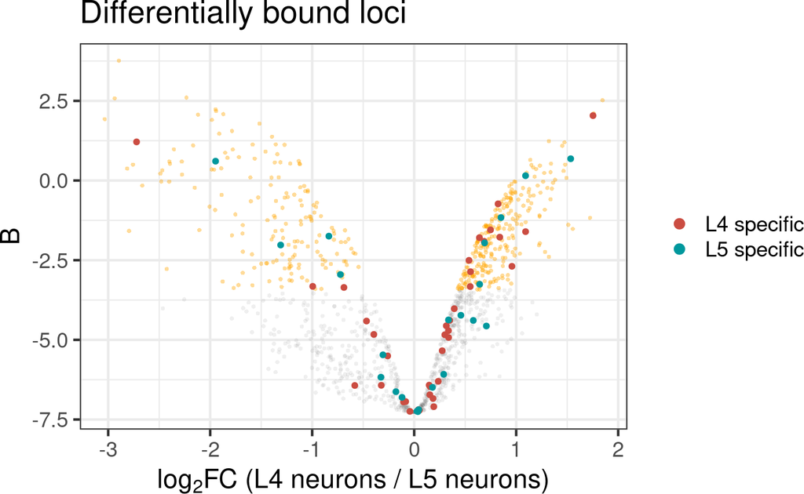

Figure 5: Differential binding of Bsh in L4 and L5 neuronal subtypes  
Genes that are specifically expressed in each subtype are highlighted. (Dataset from chromosome 2L only)

```r
L5_only_genes = c("Ptth", "Nep2", "kek1", "CG4168", "kek3", "CG6959", "Dtg", "ND-23", "Scp2", "Octalpha2R", "Hs6st", "CG16791", "SKIP", "LpR1", "RpL34a", "Ald1", "CG10011", "heph", "nolo", "Act42A","Fkbp12", "Pkc53E", "AstC-R1", "Muc14A", "CG33543", "ChAT", "Act5C", "Ptpmeg2", "fabp", "CG31221", "Octbeta1R", "CG14669", "sdk", "Shawl", "side-V", "NaCP60E", "sif", "OtopLc", "side-II", "kuz", "CG42540", "Dscam3", "haf", "CG42673", "pdm3", "tinc", "CG42750", "sdt", "Nuak1", "Hk", "scrib", "tsr", "dpr20", "GluRIB", "CG43902", "CG44242", "Dscam2", "CG44422", "lncRNA:CR45312", "Scsalpha1", "Rop", "Con", "Hsc70-3", "dpr8", "eag", "ND-18", "Nrt", "CG17839", "fz", "CG32137", "Rh7", "Sod1", "CG32052", "dpr6", "Hsp67Ba", "axed", "GluRIA", "robo2")


plot_volcano(
  diff.bsh,
  label_config = NULL,
  highlight = list(
    "L4 specific" = L4_only_genes,
    "L5 specific" = L5_only_genes
  ),
  highlight_config = list(
    size=1.5,
    label=F
  )
)
```

Here, the L5-specific Bsh peaks show no clear link with upregulated or downregulated genes between the lineages.

### 5.3.3 Browsing differentially-bound regions with an igvShiny browser window

A volcano plot, while useful, still does not put the binding data into a genomic context. For this `damidBind` provides an interactive Shiny browser window (via *Shiny* and *igvShiny*), where an interactive table of enriched loci allows quick exploration of these in the genome browser.

```r
## Interactive, blocking session, uncomment to run
# browse_igv_regions(diff.bsh)
```

An example of the interface is shown below:

[figure not shown]

The interactive IGV browser window of damidBind

### 5.3.4 GSEA plots

Gene ontology is a powerful means of understanding which biological processes may be changing between two sets of data. Using *ClusterProfiler* as the backend, `damidbind` provides the function `analyse_go_enrichment()` to explore enrichment of genes associated with bound peaks, accessible regions, or differential expression. In all cases, the underlying gene IDs, rather than gene names, are used for enrichment analysis.

```r
go.bsh_l4 = analyse_go_enrichment(
  diff.bsh,
  direction="L4",
  org_db = org.Dm.eg.db::org.Dm.eg.db
)
```

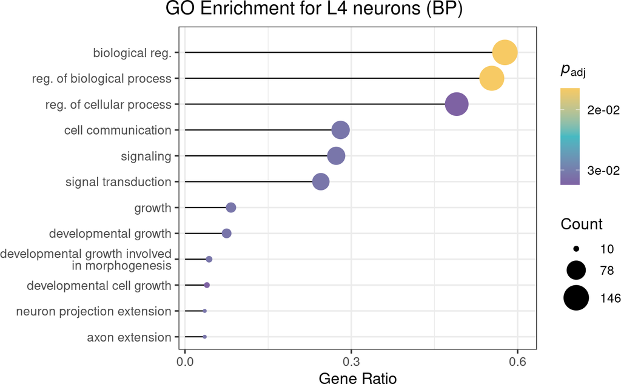

Figure 6: Enriched GO terms for genes associated with differential Bsh binding in L4 neuron  
Dataset from chromosome 2L only.

The return value of this function includes the full analysis table, including the names of all enriched loci within an ontology term.

## 5.4 Further analysis

The `DamIDResults` object returned by `differential_binding()` and `differential_accessibility()` contains a slot named `analysis` (a data.frame) that can be used for any additional downstream data exploration, filtering, or analysis. You access this slot using the `@` operator.

Below are the first 20 lines of the `analysis` slot from our `diff.bsh` object to illustrate the structure.

|  | logFC | AveExpr | t | P.Value | adj.P.Val | B | L4_mean | L5_mean | gene_names | gene_ids | minuslogp |
| --- | --- | --- | --- | --- | --- | --- | --- | --- | --- | --- | --- |
| 2L:16014990-16016485 | -2.89471214906417 | 2.295125125334225 | -24.99703328038399 | 1.960418795320856e-05 | 0.01610342559388989 | 3.758089850747226 | 0.8477690508021395 | 3.74248119986631 | beat-Ic | FBgn0028644 | 1.793081729044207 |
| 2L:13935771-13937125 | -2.232826568265683 | 0.8249243542435433 | -17.28794963407047 | 8.115229625510122e-05 | 0.01610342559388989 | 2.602373672759212 | -0.2914889298892985 | 1.941337638376385 | Ance-3 | FBgn0032536 | 1.793081729044207 |
| 2L:21921104-21922746 | -2.936331405964698 | 1.733310255629946 | -17.1675719515327 | 8.335933586664633e-05 | 0.01610342559388989 | 2.577833228435365 | 0.265144552647596 | 3.201475958612295 | CG11634 | FBgn0032968 | 1.793081729044207 |
| 2L:9894802-9896162 | 1.846422667156502 | 0.3858132806759738 | 16.89112282733457 | 8.872009714555824e-05 | 0.01610342559388989 | 2.520483305300679 | 1.309024614254225 | -0.5373980529022775 | Bka,RpS2,snoRNA:Me18S-A1576,snoRNA:Me18S-G1620,snoRNA:U14:30Ea,snoRNA:U14:30Eb,Uhg2 | FBgn0004867,FBgn0010520,FBgn0025881,FBgn0063389,FBgn0063391,FBgn0063392,FBgn0063449 | 1.793081729044207 |
| 2L:776873-777732 | -1.947571947674415 | 2.398201671511627 | -15.59741320414712 | 0.0001204296560851908 | 0.01610342559388989 | 2.232471130690826 | 1.42441569767442 | 3.371987645348835 | CG13946 | FBgn0040725 | 1.793081729044207 |
| 2L:15143784-15147420 | -1.942523886444871 | 1.606862713087709 | -15.38904760868087 | 0.0001267963164736528 | 0.01610342559388989 | 2.182840415154494 | 0.6356007698652735 | 2.578124656310145 |  |  | 1.793081729044207 |
| 2L:7181117-7182867 | 1.759428540833805 | 0.9459035908052523 | 15.08558826751977 | 0.0001368432871908522 | 0.01610342559388989 | 2.108829927006539 | 1.825617861222155 | 0.06618932038834965 | MICU1 | FBgn0031893 | 1.793081729044207 |
| 2L:18821117-18821746 | -1.871721230158728 | 0.9202554563492056 | -14.98739296362398 | 0.0001403067324515353 | 0.01610342559388989 | 2.084430895912755 | -0.01560515873015873 | 1.85611607142857 | Ugt36F1 | FBgn0027074 | 1.793081729044207 |
| 2L:7618759-7619932 | -2.11874254684838 | 0.9902688458262346 | -14.91334140616278 | 0.0001429915468138638 | 0.01610342559388989 | 2.065882477270657 | -0.06910242759795565 | 2.049640119250425 |  |  | 1.793081729044207 |
| 2L:2493025-2495386 | 1.753074724809483 | 1.124282387806943 | 14.79961383455203 | 0.0001472415577964701 | 0.01610342559388989 | 2.037144424410922 | 2.000819750211685 | 0.2477450254022015 | oaf,Slh | FBgn0011818,FBgn0264978 | 1.793081729044207 |

[output cut: 10 more lines]

# References

Aughey GN, Estacio Gomez A, Thomson J, Yin H & Southall TD (2018) [CATaDa reveals global remodelling of chromatin accessibility during stem cell differentiation in vivo](https://doi.org/10.7554/elife.32341). *eLife* 7: 1–22

Marshall OJ & Brand AH (2015) [Damidseq_pipeline: An automated pipeline for processing DamID sequencing datasets.](https://doi.org/10.1093/bioinformatics/btv386) *Bioinformatics* 31: 3371–3

Marshall OJ & Brand AH (2017) [Chromatin state changes during neural development revealed by in vivo cell-type specific profiling](https://doi.org/10.1038/s41467-017-02385-4). *Nat Commun* 8: 2271

Marshall OJ, Southall TD, Cheetham SW & Brand AH (2016) [Cell-type-specific profiling of protein–DNA interactions without cell isolation using targeted DamID with next-generation sequencing](https://doi.org/10.1038/nprot.2016.084). *Nat Protoc* 11: 1586–1598

Southall TD, Gold KS, Egger B, Davidson CM, Caygill EE, Marshall OJ & Brand AH (2013) [Cell-Type-Specific Profiling of Gene Expression and Chromatin Binding without Cell Isolation: Assaying RNA Pol II Occupancy in Neural Stem Cells.](https://doi.org/10.1016/j.devcel.2013.05.020) *Dev Cell* 26: 101–12

van Steensel B, Delrow J & Henikoff S (2001) [Chromatin profiling using targeted DNA adenine methyltransferase.](https://doi.org/10.1038/85871) *Nat Genet* 27: 304–8

van Steensel B & Henikoff S (2000) [Identification of in vivo DNA targets of chromatin proteins using tethered dam methyltransferase.](https://doi.org/10.1038/74487) *Nat Biotechnol* 18: 424–8

Xu C, Ramos TB, Marshall OJ & Doe CQ (2024) [Notch signaling and Bsh homeodomain activity are integrated to diversify Drosophila lamina neuron types](https://doi.org/10.7554/eLife.90136). *eLife* 12: RP90136